# Risk Factor Analysis

## Outcome Variable

**Outcome Variable:** ever_stunted

## Predictor Variables

**Intervention Variable:** fhtcm

**Adjustment Set:**

- arm
- W_mage
- W_fage
- meducyrs
- feducyrs
- W_mhtcm
- W_mwtkg
- W_mbmi
- single
- delta_W_mage
- delta_W_fage
- delta_meducyrs
- delta_feducyrs
- delta_W_mhtcm
- delta_W_mwtkg
- delta_W_mbmi
- delta_single

## Stratifying Variables

The analysis was stratified on these variable(s):

- agecat
- studyid
- country

## Data Summary

| agecat | studyid | country | fhtcm | ever_stunted | n_cell | n |
| --- | --- | --- | --- | --- | --- | --- |
| 0-24 months | COHORTS | GUATEMALA | >=167 cm | 0 | 16 | 496 |
| 0-24 months | COHORTS | GUATEMALA | >=167 cm | 1 | 48 | 496 |
| 0-24 months | COHORTS | GUATEMALA | <162 cm | 0 | 24 | 496 |
| 0-24 months | COHORTS | GUATEMALA | <162 cm | 1 | 269 | 496 |
| 0-24 months | COHORTS | GUATEMALA | [162-167) cm | 0 | 24 | 496 |
| 0-24 months | COHORTS | GUATEMALA | [162-167) cm | 1 | 115 | 496 |
| 0-24 months | Keneba | GAMBIA | >=167 cm | 0 | 598 | 1929 |
| 0-24 months | Keneba | GAMBIA | >=167 cm | 1 | 647 | 1929 |
| 0-24 months | Keneba | GAMBIA | <162 cm | 0 | 52 | 1929 |
| 0-24 months | Keneba | GAMBIA | <162 cm | 1 | 80 | 1929 |
| 0-24 months | Keneba | GAMBIA | [162-167) cm | 0 | 207 | 1929 |
| 0-24 months | Keneba | GAMBIA | [162-167) cm | 1 | 345 | 1929 |
| 0-24 months | PROBIT | BELARUS | >=167 cm | 0 | 10314 | 12537 |
| 0-24 months | PROBIT | BELARUS | >=167 cm | 1 | 1430 | 12537 |
| 0-24 months | PROBIT | BELARUS | <162 cm | 0 | 122 | 12537 |
| 0-24 months | PROBIT | BELARUS | <162 cm | 1 | 46 | 12537 |
| 0-24 months | PROBIT | BELARUS | [162-167) cm | 0 | 495 | 12537 |
| 0-24 months | PROBIT | BELARUS | [162-167) cm | 1 | 130 | 12537 |
| 0-24 months | SAS-CompFeed | INDIA | >=167 cm | 0 | 137 | 907 |
| 0-24 months | SAS-CompFeed | INDIA | >=167 cm | 1 | 273 | 907 |
| 0-24 months | SAS-CompFeed | INDIA | <162 cm | 0 | 50 | 907 |
| 0-24 months | SAS-CompFeed | INDIA | <162 cm | 1 | 180 | 907 |
| 0-24 months | SAS-CompFeed | INDIA | [162-167) cm | 0 | 69 | 907 |
| 0-24 months | SAS-CompFeed | INDIA | [162-167) cm | 1 | 198 | 907 |
| 0-24 months | SAS-FoodSuppl | INDIA | >=167 cm | 0 | 23 | 399 |
| 0-24 months | SAS-FoodSuppl | INDIA | >=167 cm | 1 | 83 | 399 |
| 0-24 months | SAS-FoodSuppl | INDIA | <162 cm | 0 | 15 | 399 |
| 0-24 months | SAS-FoodSuppl | INDIA | <162 cm | 1 | 148 | 399 |
| 0-24 months | SAS-FoodSuppl | INDIA | [162-167) cm | 0 | 23 | 399 |
| 0-24 months | SAS-FoodSuppl | INDIA | [162-167) cm | 1 | 107 | 399 |

[output cut: 60 more lines]

The following strata were considered:

- agecat: 0-24 months, studyid: COHORTS, country: GUATEMALA
- agecat: 0-24 months, studyid: Keneba, country: GAMBIA
- agecat: 0-24 months, studyid: PROBIT, country: BELARUS
- agecat: 0-24 months, studyid: SAS-CompFeed, country: INDIA
- agecat: 0-24 months, studyid: SAS-FoodSuppl, country: INDIA
- agecat: 0-6 months, studyid: COHORTS, country: GUATEMALA
- agecat: 0-6 months, studyid: Keneba, country: GAMBIA
- agecat: 0-6 months, studyid: PROBIT, country: BELARUS
- agecat: 0-6 months, studyid: SAS-CompFeed, country: INDIA
- agecat: 0-6 months, studyid: SAS-FoodSuppl, country: INDIA
- agecat: 6-24 months, studyid: COHORTS, country: GUATEMALA
- agecat: 6-24 months, studyid: Keneba, country: GAMBIA
- agecat: 6-24 months, studyid: PROBIT, country: BELARUS
- agecat: 6-24 months, studyid: SAS-CompFeed, country: INDIA
- agecat: 6-24 months, studyid: SAS-FoodSuppl, country: INDIA

## Methods Detail

We’re interested in the causal parameters $E[Y_a]$ for all values of $a \in \mathcal{A}$. These parameters represent the mean outcome if, possibly contrary to fact, we intervened to set all units to have $A=a$. Under the randomization and positivity assumptions, these are identified by the statistical parameters $\psi_a=E_W[E_{Y|A,W}(Y|A=a,W)]$. In addition, we’re interested in the mean of $Y$, $E[Y]$ under no intervention (the observed mean). We will estimate these parameters by using SuperLearner to fit the relevant likelihood factors – $E_{Y|A,W}(Y|A=a,W)$ and $p(A=a|W)$, and then updating our likelihood fit using a joint TMLE.

For unadjusted analyses ($W=\{\}$), initial likelihoods were estimated using Lrnr_glm to estimate the simple $E(Y|A)$ and Lrnr_mean to estimate $p(A)$. For adjusted analyses, a small library containing Lrnr_glmnet, Lrnr_xgboost, and Lrnr_mean was used.

Having estimated these parameters, we will then use the delta method to estimate relative risks and attributable risks relative to a prespecified baseline level of $A$.

# Results Detail

## Results Plots

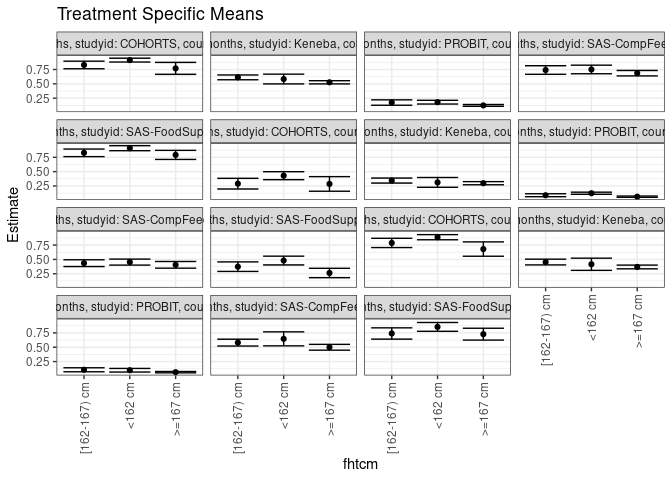

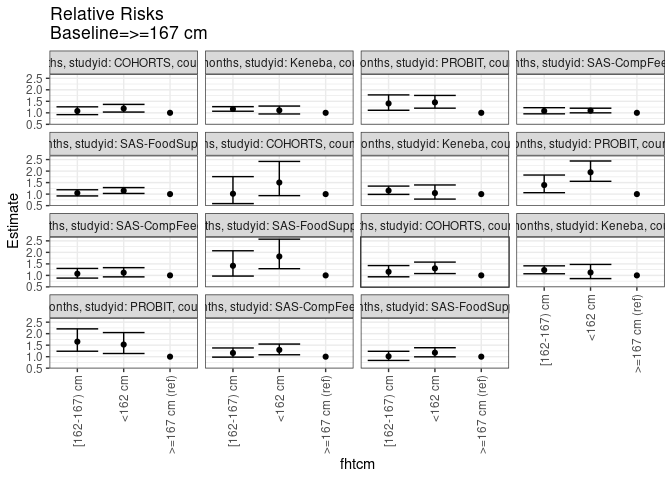

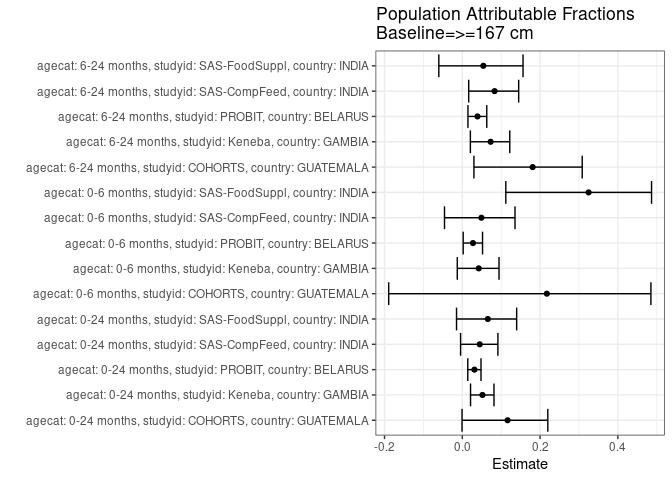

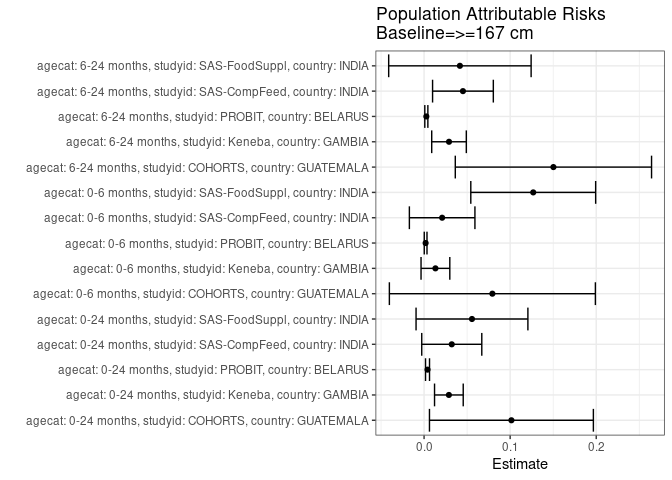

## Results Table

### Parameter: TSM

| agecat | studyid | country | intervention_level | baseline_level | estimate | ci_lower | ci_upper |
| --- | --- | --- | --- | --- | --- | --- | --- |
| 0-24 months | COHORTS | GUATEMALA | >=167 cm | NA | 0.7694939 | 0.6655547 | 0.8734330 |
| 0-24 months | COHORTS | GUATEMALA | <162 cm | NA | 0.9135652 | 0.8802943 | 0.9468362 |
| 0-24 months | COHORTS | GUATEMALA | [162-167) cm | NA | 0.8289385 | 0.7624700 | 0.8954069 |
| 0-24 months | Keneba | GAMBIA | >=167 cm | NA | 0.5269127 | 0.4987828 | 0.5550427 |
| 0-24 months | Keneba | GAMBIA | <162 cm | NA | 0.5839342 | 0.4990263 | 0.6688420 |
| 0-24 months | Keneba | GAMBIA | [162-167) cm | NA | 0.6129661 | 0.5712401 | 0.6546920 |
| 0-24 months | PROBIT | BELARUS | >=167 cm | NA | 0.1240926 | 0.1087904 | 0.1393948 |
| 0-24 months | PROBIT | BELARUS | <162 cm | NA | 0.1802822 | 0.1476224 | 0.2129420 |
| 0-24 months | PROBIT | BELARUS | [162-167) cm | NA | 0.1744275 | 0.1273464 | 0.2215085 |
| 0-24 months | SAS-CompFeed | INDIA | >=167 cm | NA | 0.6855886 | 0.6382807 | 0.7328966 |
| 0-24 months | SAS-CompFeed | INDIA | <162 cm | NA | 0.7505702 | 0.6757926 | 0.8253478 |
| 0-24 months | SAS-CompFeed | INDIA | [162-167) cm | NA | 0.7406719 | 0.6659023 | 0.8154414 |
| 0-24 months | SAS-FoodSuppl | INDIA | >=167 cm | NA | 0.7914721 | 0.7123517 | 0.8705926 |
| 0-24 months | SAS-FoodSuppl | INDIA | <162 cm | NA | 0.9086888 | 0.8650036 | 0.9523741 |
| 0-24 months | SAS-FoodSuppl | INDIA | [162-167) cm | NA | 0.8278331 | 0.7616090 | 0.8940573 |
| 0-6 months | COHORTS | GUATEMALA | >=167 cm | NA | 0.2856344 | 0.1581971 | 0.4130718 |
| 0-6 months | COHORTS | GUATEMALA | <162 cm | NA | 0.4292342 | 0.3597325 | 0.4987359 |
| 0-6 months | COHORTS | GUATEMALA | [162-167) cm | NA | 0.2902534 | 0.1973249 | 0.3831818 |
| 0-6 months | Keneba | GAMBIA | >=167 cm | NA | 0.2984817 | 0.2711748 | 0.3257886 |
| 0-6 months | Keneba | GAMBIA | <162 cm | NA | 0.3122354 | 0.2265190 | 0.3979517 |
| 0-6 months | Keneba | GAMBIA | [162-167) cm | NA | 0.3440740 | 0.3004692 | 0.3876788 |
| 0-6 months | PROBIT | BELARUS | >=167 cm | NA | 0.0634510 | 0.0524404 | 0.0744617 |
| 0-6 months | PROBIT | BELARUS | <162 cm | NA | 0.1236160 | 0.1054545 | 0.1417775 |
| 0-6 months | PROBIT | BELARUS | [162-167) cm | NA | 0.0883857 | 0.0629102 | 0.1138611 |
| 0-6 months | SAS-CompFeed | INDIA | >=167 cm | NA | 0.4055241 | 0.3473816 | 0.4636666 |
| 0-6 months | SAS-CompFeed | INDIA | <162 cm | NA | 0.4533901 | 0.4010173 | 0.5057630 |
| 0-6 months | SAS-CompFeed | INDIA | [162-167) cm | NA | 0.4349737 | 0.3758340 | 0.4941134 |
| 0-6 months | SAS-FoodSuppl | INDIA | >=167 cm | NA | 0.2636240 | 0.1818001 | 0.3454479 |
| 0-6 months | SAS-FoodSuppl | INDIA | <162 cm | NA | 0.4804130 | 0.4039920 | 0.5568341 |
| 0-6 months | SAS-FoodSuppl | INDIA | [162-167) cm | NA | 0.3736184 | 0.2902346 | 0.4570022 |
| 6-24 months | COHORTS | GUATEMALA | >=167 cm | NA | 0.6803842 | 0.5555318 | 0.8052367 |
| 6-24 months | COHORTS | GUATEMALA | <162 cm | NA | 0.8874929 | 0.8428222 | 0.9321636 |
| 6-24 months | COHORTS | GUATEMALA | [162-167) cm | NA | 0.7873514 | 0.7064815 | 0.8682213 |
| 6-24 months | Keneba | GAMBIA | >=167 cm | NA | 0.3687979 | 0.3362496 | 0.4013462 |
| 6-24 months | Keneba | GAMBIA | <162 cm | NA | 0.4156221 | 0.3093533 | 0.5218909 |
| 6-24 months | Keneba | GAMBIA | [162-167) cm | NA | 0.4540809 | 0.4041874 | 0.5039744 |
| 6-24 months | PROBIT | BELARUS | >=167 cm | NA | 0.0646533 | 0.0530253 | 0.0762813 |
| 6-24 months | PROBIT | BELARUS | <162 cm | NA | 0.0987215 | 0.0671583 | 0.1302847 |
| 6-24 months | PROBIT | BELARUS | [162-167) cm | NA | 0.1067946 | 0.0717557 | 0.1418336 |
| 6-24 months | SAS-CompFeed | INDIA | >=167 cm | NA | 0.4989882 | 0.4484602 | 0.5495162 |
| 6-24 months | SAS-CompFeed | INDIA | <162 cm | NA | 0.6460631 | 0.5238846 | 0.7682415 |
| 6-24 months | SAS-CompFeed | INDIA | [162-167) cm | NA | 0.5800966 | 0.5207037 | 0.6394895 |
| 6-24 months | SAS-FoodSuppl | INDIA | >=167 cm | NA | 0.7272917 | 0.6241620 | 0.8304215 |
| 6-24 months | SAS-FoodSuppl | INDIA | <162 cm | NA | 0.8539152 | 0.7773163 | 0.9305141 |
| 6-24 months | SAS-FoodSuppl | INDIA | [162-167) cm | NA | 0.7393223 | 0.6408728 | 0.8377719 |

### Parameter: E(Y)

| agecat | studyid | country | intervention_level | baseline_level | estimate | ci_lower | ci_upper |
| --- | --- | --- | --- | --- | --- | --- | --- |
| 0-24 months | COHORTS | GUATEMALA | NA | NA | 0.8709677 | 0.8414356 | 0.9004999 |
| 0-24 months | Keneba | GAMBIA | NA | NA | 0.5557284 | 0.5335489 | 0.5779078 |
| 0-24 months | PROBIT | BELARUS | NA | NA | 0.1281008 | 0.1120747 | 0.1441270 |
| 0-24 months | SAS-CompFeed | INDIA | NA | NA | 0.7177508 | 0.6751525 | 0.7603491 |
| 0-24 months | SAS-FoodSuppl | INDIA | NA | NA | 0.8471178 | 0.8117623 | 0.8824733 |
| 0-6 months | COHORTS | GUATEMALA | NA | NA | 0.3649852 | 0.3135088 | 0.4164615 |
| 0-6 months | Keneba | GAMBIA | NA | NA | 0.3116657 | 0.2897893 | 0.3335421 |
| 0-6 months | PROBIT | BELARUS | NA | NA | 0.0652469 | 0.0543989 | 0.0760949 |
| 0-6 months | SAS-CompFeed | INDIA | NA | NA | 0.4265193 | 0.3923837 | 0.4606550 |
| 0-6 months | SAS-FoodSuppl | INDIA | NA | NA | 0.3904282 | 0.3423793 | 0.4384771 |
| 6-24 months | COHORTS | GUATEMALA | NA | NA | 0.8306452 | 0.7924799 | 0.8688104 |
| 6-24 months | Keneba | GAMBIA | NA | NA | 0.3977695 | 0.3716030 | 0.4239360 |
| 6-24 months | PROBIT | BELARUS | NA | NA | 0.0672814 | 0.0549972 | 0.0795656 |
| 6-24 months | SAS-CompFeed | INDIA | NA | NA | 0.5441478 | 0.5023342 | 0.5859615 |
| 6-24 months | SAS-FoodSuppl | INDIA | NA | NA | 0.7689076 | 0.7152410 | 0.8225741 |

### Parameter: RR

| agecat | studyid | country | intervention_level | baseline_level | estimate | ci_lower | ci_upper |
| --- | --- | --- | --- | --- | --- | --- | --- |
| 0-24 months | COHORTS | GUATEMALA | >=167 cm | >=167 cm | 1.000000 | 1.0000000 | 1.000000 |
| 0-24 months | COHORTS | GUATEMALA | <162 cm | >=167 cm | 1.187229 | 1.0324006 | 1.365276 |
| 0-24 months | COHORTS | GUATEMALA | [162-167) cm | >=167 cm | 1.077252 | 0.9210037 | 1.260007 |
| 0-24 months | Keneba | GAMBIA | >=167 cm | >=167 cm | 1.000000 | 1.0000000 | 1.000000 |
| 0-24 months | Keneba | GAMBIA | <162 cm | >=167 cm | 1.108218 | 0.9495870 | 1.293349 |
| 0-24 months | Keneba | GAMBIA | [162-167) cm | >=167 cm | 1.163316 | 1.0680301 | 1.267103 |
| 0-24 months | PROBIT | BELARUS | >=167 cm | >=167 cm | 1.000000 | 1.0000000 | 1.000000 |
| 0-24 months | PROBIT | BELARUS | <162 cm | >=167 cm | 1.452804 | 1.2023182 | 1.755475 |
| 0-24 months | PROBIT | BELARUS | [162-167) cm | >=167 cm | 1.405624 | 1.1105706 | 1.779066 |
| 0-24 months | SAS-CompFeed | INDIA | >=167 cm | >=167 cm | 1.000000 | 1.0000000 | 1.000000 |
| 0-24 months | SAS-CompFeed | INDIA | <162 cm | >=167 cm | 1.094782 | 0.9982849 | 1.200607 |
| 0-24 months | SAS-CompFeed | INDIA | [162-167) cm | >=167 cm | 1.080344 | 0.9553606 | 1.221679 |
| 0-24 months | SAS-FoodSuppl | INDIA | >=167 cm | >=167 cm | 1.000000 | 1.0000000 | 1.000000 |
| 0-24 months | SAS-FoodSuppl | INDIA | <162 cm | >=167 cm | 1.148100 | 1.0280386 | 1.282182 |
| 0-24 months | SAS-FoodSuppl | INDIA | [162-167) cm | >=167 cm | 1.045941 | 0.9206334 | 1.188304 |
| 0-6 months | COHORTS | GUATEMALA | >=167 cm | >=167 cm | 1.000000 | 1.0000000 | 1.000000 |
| 0-6 months | COHORTS | GUATEMALA | <162 cm | >=167 cm | 1.502740 | 0.9335987 | 2.418842 |
| 0-6 months | COHORTS | GUATEMALA | [162-167) cm | >=167 cm | 1.016171 | 0.5872596 | 1.758342 |
| 0-6 months | Keneba | GAMBIA | >=167 cm | >=167 cm | 1.000000 | 1.0000000 | 1.000000 |
| 0-6 months | Keneba | GAMBIA | <162 cm | >=167 cm | 1.046079 | 0.7834444 | 1.396756 |
| 0-6 months | Keneba | GAMBIA | [162-167) cm | >=167 cm | 1.152747 | 0.9867082 | 1.346727 |
| 0-6 months | PROBIT | BELARUS | >=167 cm | >=167 cm | 1.000000 | 1.0000000 | 1.000000 |
| 0-6 months | PROBIT | BELARUS | <162 cm | >=167 cm | 1.948210 | 1.5568269 | 2.437986 |
| 0-6 months | PROBIT | BELARUS | [162-167) cm | >=167 cm | 1.392974 | 1.0616936 | 1.827624 |
| 0-6 months | SAS-CompFeed | INDIA | >=167 cm | >=167 cm | 1.000000 | 1.0000000 | 1.000000 |
| 0-6 months | SAS-CompFeed | INDIA | <162 cm | >=167 cm | 1.118035 | 0.9361099 | 1.335316 |
| 0-6 months | SAS-CompFeed | INDIA | [162-167) cm | >=167 cm | 1.072621 | 0.8831436 | 1.302750 |
| 0-6 months | SAS-FoodSuppl | INDIA | >=167 cm | >=167 cm | 1.000000 | 1.0000000 | 1.000000 |
| 0-6 months | SAS-FoodSuppl | INDIA | <162 cm | >=167 cm | 1.822342 | 1.2905123 | 2.573342 |
| 0-6 months | SAS-FoodSuppl | INDIA | [162-167) cm | >=167 cm | 1.417240 | 0.9707266 | 2.069139 |
| 6-24 months | COHORTS | GUATEMALA | >=167 cm | >=167 cm | 1.000000 | 1.0000000 | 1.000000 |
| 6-24 months | COHORTS | GUATEMALA | <162 cm | >=167 cm | 1.304400 | 1.0783052 | 1.577900 |
| 6-24 months | COHORTS | GUATEMALA | [162-167) cm | >=167 cm | 1.157216 | 0.9383911 | 1.427069 |
| 6-24 months | Keneba | GAMBIA | >=167 cm | >=167 cm | 1.000000 | 1.0000000 | 1.000000 |
| 6-24 months | Keneba | GAMBIA | <162 cm | >=167 cm | 1.126964 | 0.8604719 | 1.475991 |
| 6-24 months | Keneba | GAMBIA | [162-167) cm | >=167 cm | 1.231246 | 1.0710805 | 1.415362 |
| 6-24 months | PROBIT | BELARUS | >=167 cm | >=167 cm | 1.000000 | 1.0000000 | 1.000000 |
| 6-24 months | PROBIT | BELARUS | <162 cm | >=167 cm | 1.526937 | 1.1389438 | 2.047105 |
| 6-24 months | PROBIT | BELARUS | [162-167) cm | >=167 cm | 1.651805 | 1.2356171 | 2.208176 |
| 6-24 months | SAS-CompFeed | INDIA | >=167 cm | >=167 cm | 1.000000 | 1.0000000 | 1.000000 |
| 6-24 months | SAS-CompFeed | INDIA | <162 cm | >=167 cm | 1.294746 | 1.0827519 | 1.548247 |
| 6-24 months | SAS-CompFeed | INDIA | [162-167) cm | >=167 cm | 1.162546 | 0.9803834 | 1.378555 |
| 6-24 months | SAS-FoodSuppl | INDIA | >=167 cm | >=167 cm | 1.000000 | 1.0000000 | 1.000000 |
| 6-24 months | SAS-FoodSuppl | INDIA | <162 cm | >=167 cm | 1.174103 | 0.9926634 | 1.388706 |
| 6-24 months | SAS-FoodSuppl | INDIA | [162-167) cm | >=167 cm | 1.016542 | 0.8372851 | 1.234176 |

### Parameter: PAR

| agecat | studyid | country | intervention_level | baseline_level | estimate | ci_lower | ci_upper |
| --- | --- | --- | --- | --- | --- | --- | --- |
| 0-24 months | COHORTS | GUATEMALA | >=167 cm | NA | 0.1014739 | 0.0062655 | 0.1966823 |
| 0-24 months | Keneba | GAMBIA | >=167 cm | NA | 0.0288156 | 0.0121539 | 0.0454773 |
| 0-24 months | PROBIT | BELARUS | >=167 cm | NA | 0.0040082 | 0.0016909 | 0.0063256 |
| 0-24 months | SAS-CompFeed | INDIA | >=167 cm | NA | 0.0321622 | -0.0027182 | 0.0670425 |
| 0-24 months | SAS-FoodSuppl | INDIA | >=167 cm | NA | 0.0556457 | -0.0093174 | 0.1206088 |
| 0-6 months | COHORTS | GUATEMALA | >=167 cm | NA | 0.0793507 | -0.0403191 | 0.1990206 |
| 0-6 months | Keneba | GAMBIA | >=167 cm | NA | 0.0131840 | -0.0035226 | 0.0298906 |
| 0-6 months | PROBIT | BELARUS | >=167 cm | NA | 0.0017958 | 0.0002089 | 0.0033828 |
| 0-6 months | SAS-CompFeed | INDIA | >=167 cm | NA | 0.0209952 | -0.0170810 | 0.0590714 |
| 0-6 months | SAS-FoodSuppl | INDIA | >=167 cm | NA | 0.1268042 | 0.0542750 | 0.1993335 |
| 6-24 months | COHORTS | GUATEMALA | >=167 cm | NA | 0.1502609 | 0.0362608 | 0.2642611 |
| 6-24 months | Keneba | GAMBIA | >=167 cm | NA | 0.0289717 | 0.0088707 | 0.0490726 |
| 6-24 months | PROBIT | BELARUS | >=167 cm | NA | 0.0026281 | 0.0008517 | 0.0044046 |
| 6-24 months | SAS-CompFeed | INDIA | >=167 cm | NA | 0.0451596 | 0.0098738 | 0.0804455 |
| 6-24 months | SAS-FoodSuppl | INDIA | >=167 cm | NA | 0.0416158 | -0.0411231 | 0.1243547 |

### Parameter: PAF

| agecat | studyid | country | intervention_level | baseline_level | estimate | ci_lower | ci_upper |
| --- | --- | --- | --- | --- | --- | --- | --- |
| 0-24 months | COHORTS | GUATEMALA | >=167 cm | NA | 0.1165070 | -0.0006243 | 0.2199272 |
| 0-24 months | Keneba | GAMBIA | >=167 cm | NA | 0.0518520 | 0.0212549 | 0.0814925 |
| 0-24 months | PROBIT | BELARUS | >=167 cm | NA | 0.0312897 | 0.0141369 | 0.0481442 |
| 0-24 months | SAS-CompFeed | INDIA | >=167 cm | NA | 0.0448097 | -0.0043700 | 0.0915812 |
| 0-24 months | SAS-FoodSuppl | INDIA | >=167 cm | NA | 0.0656882 | -0.0147972 | 0.1397903 |
| 0-6 months | COHORTS | GUATEMALA | >=167 cm | NA | 0.2174081 | -0.1892544 | 0.4850134 |
| 0-6 months | Keneba | GAMBIA | >=167 cm | NA | 0.0423017 | -0.0128664 | 0.0944649 |
| 0-6 months | PROBIT | BELARUS | >=167 cm | NA | 0.0275235 | 0.0023181 | 0.0520921 |
| 0-6 months | SAS-CompFeed | INDIA | >=167 cm | NA | 0.0492245 | -0.0457341 | 0.1355603 |
| 0-6 months | SAS-FoodSuppl | INDIA | >=167 cm | NA | 0.3247824 | 0.1118845 | 0.4866447 |
| 6-24 months | COHORTS | GUATEMALA | >=167 cm | NA | 0.1808966 | 0.0299124 | 0.3083818 |
| 6-24 months | Keneba | GAMBIA | >=167 cm | NA | 0.0728353 | 0.0208000 | 0.1221054 |
| 6-24 months | PROBIT | BELARUS | >=167 cm | NA | 0.0390617 | 0.0145602 | 0.0629540 |
| 6-24 months | SAS-CompFeed | INDIA | >=167 cm | NA | 0.0829915 | 0.0164857 | 0.1450001 |
| 6-24 months | SAS-FoodSuppl | INDIA | >=167 cm | NA | 0.0541233 | -0.0603492 | 0.1562377 |